# RR_Prog-1

lamcd

19/08/2020

Reproducible Research - Programming Assignment 1 The .csv file is in the working directory

Initializing, reading and converting data - question 1

```r
knitr::opts_chunk$set(echo = TRUE)
rm(list=ls())
library("knitr")
require("ggplot2")
library("plyr")

## read data and take a look at the file
activity <- read.csv("activity.csv")
summary(activity)
```

```
##      steps            date              interval
##  Min.   :  0.00   Length:17568       Min.   :   0.0
##  1st Qu.:  0.00   Class :character   1st Qu.: 588.8
##  Median :  0.00   Mode  :character   Median :1177.5
##  Mean   : 37.38                      Mean   :1177.5
##  3rd Qu.: 12.00                      3rd Qu.:1766.2
##  Max.   :806.00                      Max.   :2355.0
##  NA's   :2304
```

```r
## convert Date column from char to type date variables
activity$date <- as.Date(activity$date)
str(activity)
```

```
## 'data.frame':    17568 obs. of  3 variables:
##  $ steps   : int  NA NA NA NA NA NA NA NA NA NA ...
##  $ date    : Date, format: "2012-10-01" "2012-10-01" ...
##  $ interval: int  0 5 10 15 20 25 30 35 40 45 ...
```

Histo of total number of steps per day - question 2 Find how many missing values in the activity data Remove missing values from activity column and create ‘clean’ per-day data Aggregate the data (steps) by day and plot histogram - question 2

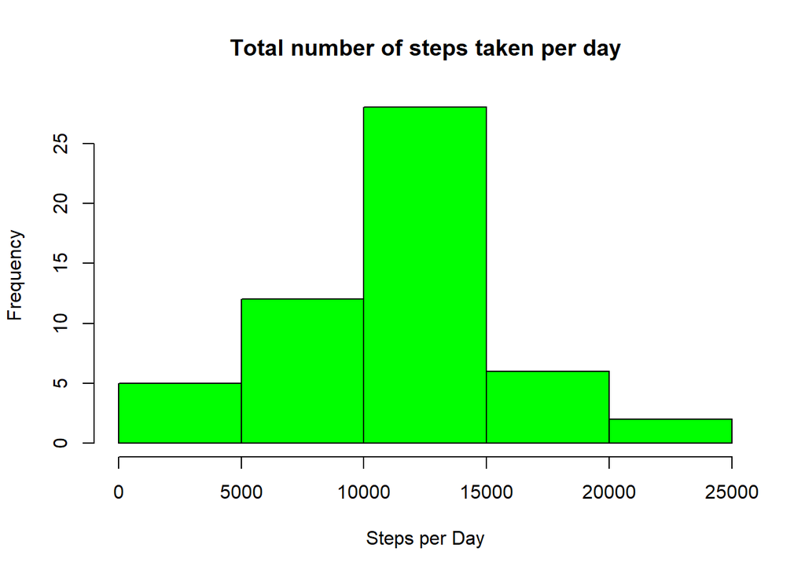

```r
## histo of total number of steps per day - question 2
activity_steps_day <- aggregate(steps ~ date, data = activity, FUN = sum, na.rm = TRUE)
hist(activity_steps_day$steps, xlab = "Steps per Day", main = "Total number of steps taken per day", col = "green")
```

```r
## find how many missing values in the activity data
sum(is.na(activity$steps))
```

```
## [1] 2304
```

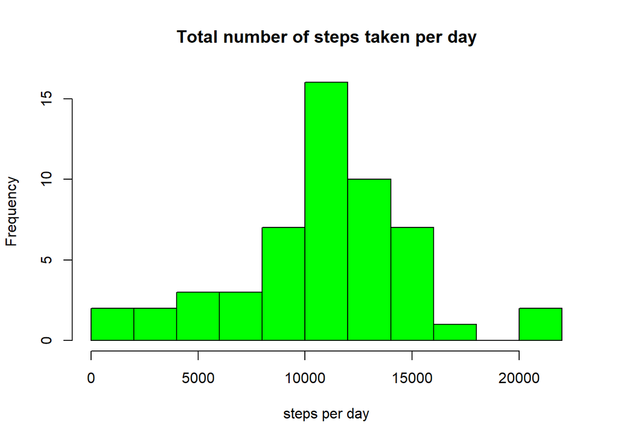

```r
## remove missing values from activity column and create 'clean' per-day data
activity_rm <- activity[which(!is.na(activity$steps)),]

## aggregate the data (steps) by day and plot histogram - question 2
perday <- tapply(activity_rm$steps, activity_rm$date, sum)
hist(perday, 10, main = "Total number of steps taken per day", xlab = "steps per day", col = "green")
```

Calculate and display mean and median of steps-per-day - question 3

```r
mean(perday)
```

```
## [1] 10766.19
```

```r
median(perday)
```

```
## [1] 10765
```

```r
## to analyse a daily mean activity we will aggregate the data (steps) by interval
## accross days in the data set
dailyact <- tapply(activity_rm$steps, activity_rm$interval, mean)
```

Plot the daily average number of steps - question 4

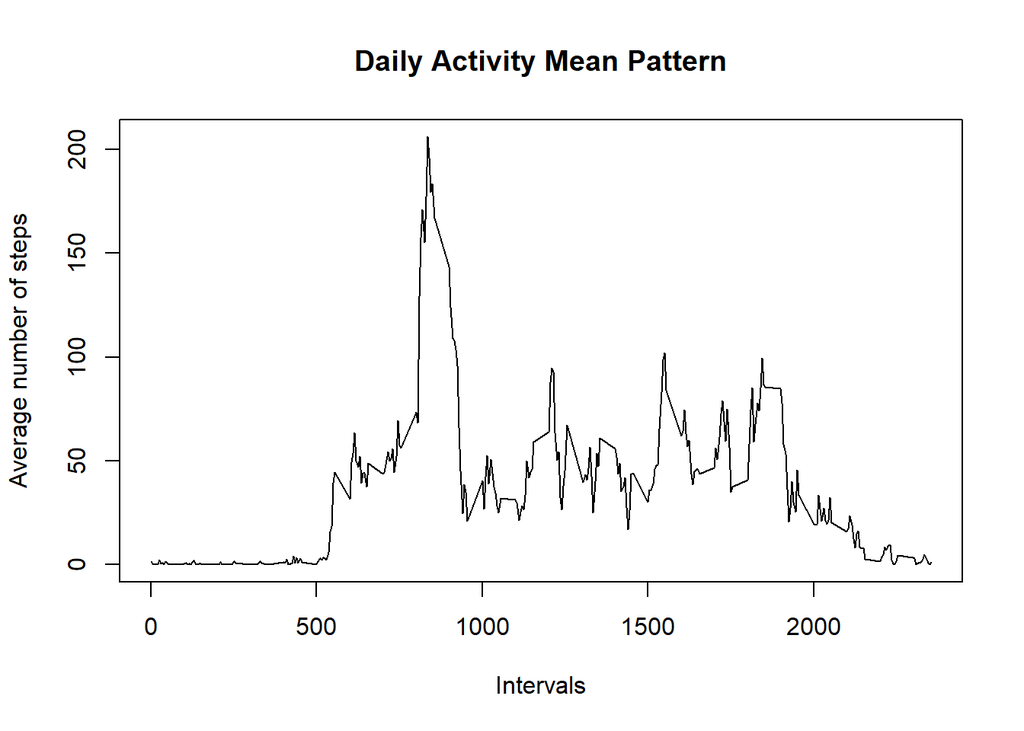

```r
## plot the daily average number of steps - question 4
plot(y = dailyact, x = names(dailyact), type = "l", xlab = "Intervals",
     main = "Daily Activity Mean Pattern", ylab = "Average number of steps")
```

Find the 5-minute interval that contains (on average) the maximun number of steps and that maximum value - question 5

```r
## find the 5-minute interval that contains (on average) the maximun number of steps
## and that maximum value - question 5
dailyact[dailyact==max(dailyact)]
```

```
##      835
## 206.1698
```

```r
## interval 835, with 206.2 steps
```

Define a strategy for imputing missing data - question 6 (start) Determining where the missing values are in the data set

So, all the missing data is in the activity variable Furthermore 2304 missing values is a considerable number - approximately 13%, so some fixing is needed. An intuitive processe will be to replace the missing values with mean or median for the day or the 5-minute interval

To start a new data set is created with missing values replaced by interval means act_new <- activity act_new[which(is.na(act_new$steps)),1]<- dailyact[as.character(act_new[which(is.na(act_new$steps)),3])]

Checking if there are remaining missing values There are no remaining missing values

To decide about a strategy for imputing missing data 2 histos are plotted: The original (removing NAs) and the new imputing interval mean - question 6 perday_new<-tapply(act_new$steps, act_new$date, sum)

```r
## define a strategy for imputing missing data - question 6 (start)
## determining where the missing values are in the data set
## missing data in the activity (steps) variable:
sum(is.na(activity$steps))
```

```
## [1] 2304
```

```r
## missing data in the complete data set:
sum(is.na(activity))
```

```
## [1] 2304
```

```r
## so, all the missing data is in the activity variable
## furthermore 2304 missing values is a considerable number -
## approximately 13%, so some fixing is needed.
## an intuitive processe will be to replace the missing values with mean or median
## for the day or the 5-minute interval

## to start a new data set is created with missing values replaced by interval means
act_new <- activity
act_new[which(is.na(act_new$steps)),1]<-
  dailyact[as.character(act_new[which(is.na(act_new$steps)),3])]

## checking if there are remaining missing values
sum(is.na(act_new))
```

```
## [1] 0
```

```r
## there are no remaining missing values

## to decide about a strategy for imputing missing data 2 histos are plotted:
## the original (removing NAs) and the new imputing interval mean - question 6
perday_new<-tapply(act_new$steps, act_new$date, sum)
```

Histo’s with same scale in Y-axis to facilitate comparison - question 7 Calculate and display mean and median after imputing NAs

So, imputing the missing data had little impact in either mean or median

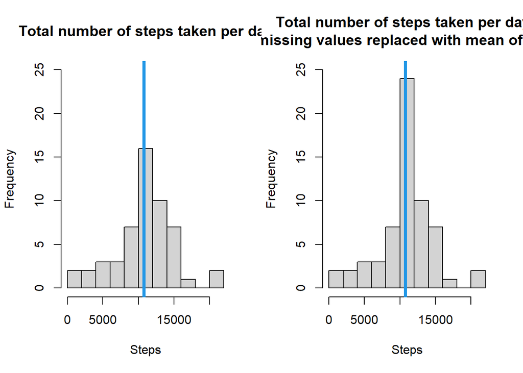

```r
## histo's with same scale in Y-axis to facilitate comparison - question 7
par(mfrow=c(1,2))
hist(perday,10, main = "Total number of steps taken per day", xlab = "Steps"
     , ylim =c(0, 25))
abline(v = median(perday), col = 4, lwd = 4)
hist(perday_new,10, main = "Total number of steps taken per day
     (missing values replaced with mean of interval)", xlab = "Steps",
     ylim =c(0, 25))
abline(v = median(perday_new), col = 4, lwd = 4)
```

```r
dev.copy(png, file="plot5.png", height=480, width=480)
```

```r
## calculate and display mean and median after imputing NAs
mean(perday_new)
```

```
## [1] 10766.19
```

```r
median(perday_new)
```

```
## [1] 10766.19
```

```r
## so, imputing the missing data had little impact in either mean or median
```

Studying the difference between activity during weekdays and weekends - question 8 to start create a factor with two levels - “weekend” and “weekday” split the data into two sets (weekdays - weekends) to make separate plots data is still steps over 5-minute interval The classification (weekday/weekend) is adapted to the language setting (sunday = domingo / saturday = sabado)

Simple plotting with base system

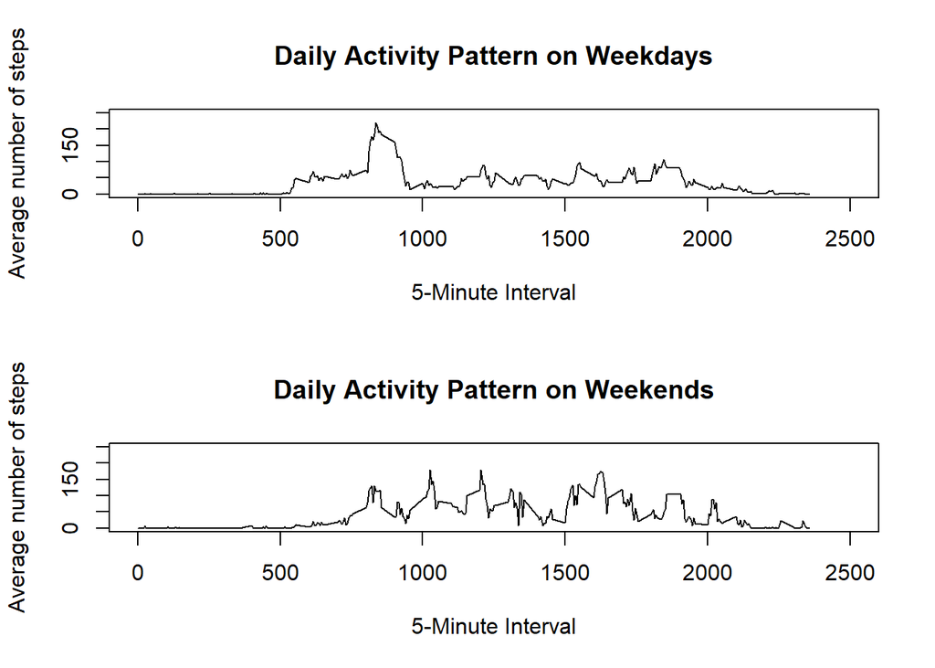

```r
## studying the difference between activity during weekdays and weekends - question 8

## to start create a factor with two levels - "weekend" and "weekday"
## test adjusted to language: domingo / sabado
act_new$wd <- weekdays(act_new$date)
act_new$fwd <- as.factor(c("weekend", "weekday"))
act_new[act_new$wd == "domingo" | act_new$wd == "sabado" ,5] <- factor("weekend")
act_new[!(act_new$wd == "domingo" | act_new$wd == "sabado"),5 ] <- factor("weekday")

## split the data into two sets (weekdays - weekends) to make separate plots
## data is still steps over 5-minute interval
## simple plotting with base system
act_new_we <- subset(act_new, fwd == "weekend")
act_new_wd <- subset(act_new, fwd == "weekday")
dailyact_we <- tapply(act_new_we$steps, act_new_we$interval, mean)
dailyact_wd <- tapply(act_new_wd$steps, act_new_wd$interval, mean)

par(mfrow=c(2,1))
plot(y = dailyact_wd, x = names(dailyact_wd), type = "l", xlab = "5-Minute Interval",
     main = "Daily Activity Pattern on Weekdays", ylab = "Average number of steps",
     xlim = c(0, 2500), ylim = c(0, 250))
plot(y = dailyact_we, x = names(dailyact_we), type = "l", xlab = "5-Minute Interval",
     main = "Daily Activity Pattern on Weekends", ylab = "Average number of steps",
     xlim = c(0, 2500), ylim = c(0, 250))
```

```r
## Analysis
```

So, the pattern of activity for weekdays is different from that of weenkends On weekdays the activity seems to start earlier On weekdays there seems to be a peak of activity in earlier hours then decreases On weekends the activity spreads more uniformly across the day